# Improving Visualizations with `ggplot2`

Material adapted from *“Programming Skills for Data Science”* (PSDS) by Freeman and Ross.

Load the required packages

```r
library(tidyverse)
```

## Data

We will be using the `midwest` [dataframe](https://www.rdocumentation.org/packages/ggplot2/versions/3.3.0/topics/midwest), a built-in dataset from `ggplot2` that contains demographic information of midwest counties. There are 437 counties in 5 states in the midwestern United States (Illinois, Indiana, Michigan, Ohio, and Wisconsin). To learn more about the dataset you can use `?midwest`

```r
glimpse(midwest)
```

```
Rows: 437
Columns: 28
$ PID                  <int> 561, 562, 563, 564, 565, 566, 567, 568, 569, 570, 571, 572, 573, 574, 575, 576, 577, 578, 579, 580, 581, 582, 583, 584, 585, 586, 587, 588, 58~
$ county               <chr> "ADAMS", "ALEXANDER", "BOND", "BOONE", "BROWN", "BUREAU", "CALHOUN", "CARROLL", "CASS", "CHAMPAIGN", "CHRISTIAN", "CLARK", "CLAY", "CLINTON", ~
$ state                <chr> "IL", "IL", "IL", "IL", "IL", "IL", "IL", "IL", "IL", "IL", "IL", "IL", "IL", "IL", "IL", "IL", "IL", "IL", "IL", "IL", "IL", "IL", "IL", "IL"~
$ area                 <dbl> 0.052, 0.014, 0.022, 0.017, 0.018, 0.050, 0.017, 0.027, 0.024, 0.058, 0.042, 0.030, 0.028, 0.029, 0.030, 0.058, 0.026, 0.020, 0.038, 0.023, 0.~
$ poptotal             <int> 66090, 10626, 14991, 30806, 5836, 35688, 5322, 16805, 13437, 173025, 34418, 15921, 14460, 33944, 51644, 5105067, 19464, 10670, 77932, 16516, 1~
$ popdensity           <dbl> 1270.9615, 759.0000, 681.4091, 1812.1176, 324.2222, 713.7600, 313.0588, 622.4074, 559.8750, 2983.1897, 819.4762, 530.7000, 516.4286, 1170.4828~
$ popwhite             <int> 63917, 7054, 14477, 29344, 5264, 35157, 5298, 16519, 13384, 146506, 34176, 15842, 14403, 32688, 50177, 3204947, 19300, 10627, 72968, 16387, 19~
$ popblack             <int> 1702, 3496, 429, 127, 547, 50, 1, 111, 16, 16559, 82, 10, 4, 1021, 925, 1317147, 63, 5, 2069, 25, 16, 15462, 68, 6, 12, 599, 43, 36, 668, 42, ~
$ popamerindian        <int> 98, 19, 35, 46, 14, 65, 8, 30, 8, 331, 51, 26, 17, 48, 92, 10289, 34, 6, 123, 37, 19, 962, 24, 8, 45, 40, 14, 106, 83, 10, 50, 45, 11, 25, 16,~
$ popasian             <int> 249, 48, 16, 150, 5, 195, 15, 61, 23, 8033, 89, 36, 29, 104, 341, 188565, 48, 26, 1751, 43, 41, 39634, 24, 19, 95, 35, 40, 84, 105, 11, 17, 11~
$ popother             <int> 124, 9, 34, 1139, 6, 221, 0, 84, 6, 1596, 20, 7, 7, 83, 109, 384119, 19, 6, 1021, 24, 108, 10703, 10, 6, 29, 71, 21, 25, 107, 4, 5, 294, 2, 13~
$ percwhite            <dbl> 96.71206, 66.38434, 96.57128, 95.25417, 90.19877, 98.51210, 99.54904, 98.29813, 99.60557, 84.67331, 99.29688, 99.50380, 99.60581, 96.29979, 97~
$ percblack            <dbl> 2.57527614, 32.90043290, 2.86171703, 0.41225735, 9.37285812, 0.14010312, 0.01878993, 0.66051770, 0.11907420, 9.57029331, 0.23824743, 0.0628101~
$ percamerindan        <dbl> 0.14828264, 0.17880670, 0.23347342, 0.14932156, 0.23989034, 0.18213405, 0.15031943, 0.17851830, 0.05953710, 0.19130183, 0.14817828, 0.16330632~
$ percasian            <dbl> 0.37675897, 0.45172219, 0.10673071, 0.48691813, 0.08567512, 0.54640215, 0.28184893, 0.36298721, 0.17116916, 4.64268169, 0.25858562, 0.22611645~
$ percother            <dbl> 0.18762294, 0.08469791, 0.22680275, 3.69733169, 0.10281014, 0.61925577, 0.00000000, 0.49985123, 0.04465282, 0.92241006, 0.05810913, 0.04396709~
$ popadults            <int> 43298, 6724, 9669, 19272, 3979, 23444, 3583, 11323, 8825, 95971, 22945, 10734, 9647, 21563, 29136, 3291995, 13317, 6727, 41817, 10941, 12550, ~
$ perchsd              <dbl> 75.10740, 59.72635, 69.33499, 75.47219, 68.86152, 76.62941, 62.82445, 75.95160, 72.27195, 87.49935, 73.07474, 71.33408, 65.56442, 67.16598, 76~
$ percollege           <dbl> 19.63139, 11.24331, 17.03382, 17.27895, 14.47600, 18.90462, 11.91739, 16.19712, 14.10765, 41.29581, 13.56723, 15.11086, 13.68301, 15.38747, 25~
$ percprof             <dbl> 4.355859, 2.870315, 4.488572, 4.197800, 3.367680, 3.275891, 3.209601, 3.055727, 3.206799, 17.757448, 3.089998, 2.776225, 2.788432, 2.875296, 8~
$ poppovertyknown      <int> 63628, 10529, 14235, 30337, 4815, 35107, 5241, 16455, 13081, 154934, 33788, 15615, 14248, 32190, 45693, 5023523, 19123, 10590, 69127, 16238, 1~
$ percpovertyknown     <dbl> 96.27478, 99.08714, 94.95697, 98.47757, 82.50514, 98.37200, 98.47802, 97.91729, 97.35060, 89.54429, 98.16956, 98.07801, 98.53389, 94.83267, 88~
$ percbelowpoverty     <dbl> 13.151443, 32.244278, 12.068844, 7.209019, 13.520249, 10.399635, 15.149781, 11.710726, 13.875086, 15.572437, 11.708299, 12.007685, 16.774284, ~
$ percchildbelowpovert <dbl> 18.011717, 45.826514, 14.036061, 11.179536, 13.022889, 14.158819, 13.787761, 17.225462, 17.994784, 14.132234, 16.320612, 15.321547, 20.582578,~
$ percadultpoverty     <dbl> 11.009776, 27.385647, 10.852090, 5.536013, 11.143211, 8.179287, 12.932331, 10.027037, 11.914343, 17.562728, 9.569700, 10.131775, 14.464114, 9.~
$ percelderlypoverty   <dbl> 12.443812, 25.228976, 12.697410, 6.217047, 19.200000, 11.008586, 21.085271, 9.525052, 13.660180, 8.105017, 11.490641, 12.595420, 17.670078, 8.~
$ inmetro              <int> 0, 0, 0, 1, 0, 0, 0, 0, 0, 1, 0, 0, 0, 1, 0, 1, 0, 0, 1, 0, 0, 1, 0, 0, 0, 0, 0, 0, 0, 0, 0, 1, 0, 0, 0, 0, 1, 0, 0, 0, 0, 1, 0, 0, 1, 1, 1, 0~
$ category             <chr> "AAR", "LHR", "AAR", "ALU", "AAR", "AAR", "LAR", "AAR", "AAR", "HAU", "AAR", "AAR", "LAR", "LAU", "AAR", "AAU", "AAR", "AAR", "HAU", "AAR", "A~
```

## Basic Plotting

We can check the association between the percentage of people with a college education (`percollege`) and the percentage of adults living in poverty (`percadultpoverty`) in counties in the Midwest.

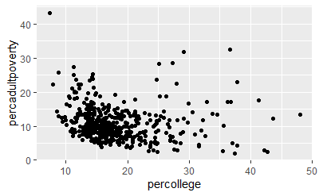

```r
ggplot(data = midwest) +
  geom_point(aes(x = percollege, y = percadultpoverty))
```

## Bar Chart

Let us create a bar chart of the total population of each state:

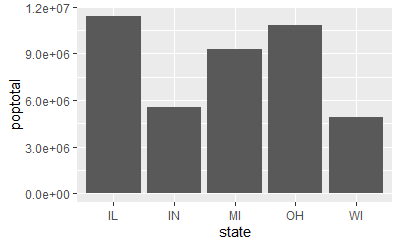

```r
ggplot(data = midwest) +
  geom_col(aes(x = state, y = poptotal))
```

## Hexagonal Aggregation

A hexagonal aggregation that counts the co-occurrence of college education rate and percentage of adult poverty is created below:

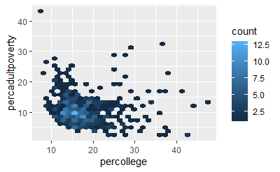

```r
ggplot(data = midwest) +
  geom_hex(aes(x = percollege, y = percadultpoverty))
```

## Multiple Geometries

What makes `ggplot2` a powerful tool is that you can *add* multiple geometries to a plot. This allows you to create complex graphics showing multiple aspects of your data. For example, below we create a plot with both points and a smoothed line.

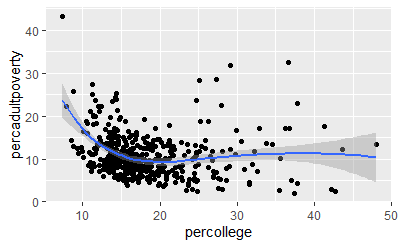

```r
ggplot(data = midwest, aes(x = percollege, y = percadultpoverty)) +
  geom_point() +
  geom_smooth()
```

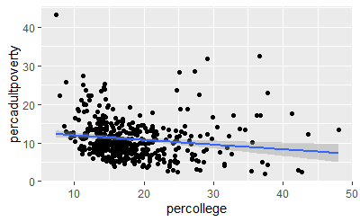

```r
ggplot(data = midwest, aes(x = percollege, y = percadultpoverty)) +
  geom_point() +
  geom_smooth(method = "lm")
```

Notice that if the layers share some aesthetics mappings, you can specify those as an argument to the `ggplot()` function call.

## Aesthetics Mappings

The aesthetic mappings take properties of the data and use them to influence visual channels (*graphical encodings*), such as position, color, size, or shape. Each visual channel therefore encodes a feature of the data and can be used to express that data. Aesthetic mappings are used for visual features that should be driven by data values, rather than set for all geometric elements. For example, if you want to use a color encoding to express the values in a column, you would use an aesthetic mapping. In contrast, if you want the color of all points to be the same (e.g., blue), you would not use an aesthetic mapping (because the color has nothing to do with your data).

The data-driven aesthetics for a plot are specified using the `aes()` function and passed into a particular `geom_` function layer. For example, if you want to know which *state* each county is in, you can add a *mapping* from the `state` feature of each row to the `color` channel. `ggplot2` will even create a legend for you automatically. Note that using the `aes()` function will cause the visual channel to be based on the data specified in the argument.

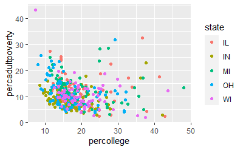

```r
ggplot(data = midwest) +
  geom_point(aes(x = percollege, y = percadultpoverty, color = state))
```

Conversely, if you wish to apply a *visual property* to an entire geometry, you can set that property on the geometry by passing it as an argument to the `geom_` function, outside of the `aes()` call:

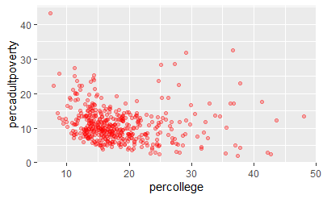

```r
ggplot(data = midwest) +
  geom_point(aes(x = percollege, y = percadultpoverty),
             color = "red", alpha = 0.3)
```

## Position Adjustments

The plot above using `geom_col()` stacked all of the observations (rows) per state into a single column. This stacking is the default *position adjustment* for the geometry, which specifies a “rule” as to how different components should be positioned relative to each other to make sure they do not overlap. This positional adjustment can be made more apparent if you map a different variable to the color encoding (using the `fill` aesthetic).

For example, below you can see the racial breakdown for the population in each state by adding a `fill` to the column geometry:

First we wrangle the data using `tidyr` and `dplyr`: select the columns for racial population totals, and then `gather()` those column values into `race` and `population` columns

```r
midwest %>%
  select(state, popwhite, popblack, popamerindian, popasian, popother) %>%
  gather(key = race, value = population, -state) # all columns except state
```

| state | race | population |
| --- | --- | --- |
| IL | popwhite | 63917 |
| IL | popwhite | 7054 |
| IL | popwhite | 14477 |
| IL | popwhite | 29344 |
| IL | popwhite | 5264 |
| IL | popwhite | 35157 |
| IL | popwhite | 5298 |
| IL | popwhite | 16519 |
| IL | popwhite | 13384 |
| IL | popwhite | 146506 |

[output cut: 990 more lines]

An equivalent solution can be obtained using `pivot_longer()`, as shown below

```r
state_race_long <- midwest %>%
  select(state, popwhite, popblack, popamerindian, popasian, popother) %>%
  pivot_longer(cols = -state, names_to = "race", values_to = "population")
```

We now create the stacked bar chart of the number of people in each state, filling the bars using different colors to show racial composition:

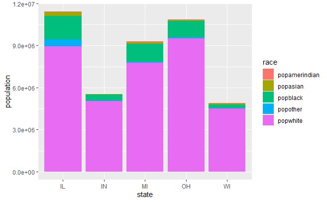

```r
ggplot(data = state_race_long) +
  geom_col(aes(x = state, y = population, fill = race))
```

**Improvements**

By default, `ggplot` will adjust the position of each rectangle by stacking the “columns” for each county. The plot thus shows all of the elements instead of causing them to overlap. However, if you wish to specify a different position adjustment, you can use the `position` argument. For example, to see the relative composition (e.g., percentage) of people by race in each state, you can use a `"fill"` position (to fill each bar to 100%).

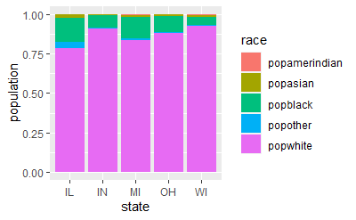

```r
ggplot(data = state_race_long) +
  geom_col(aes(x = state, y = population, fill = race),
           position = "fill")
```

To see the relative measures within each state side by side, you can use a `"dodge"` position.

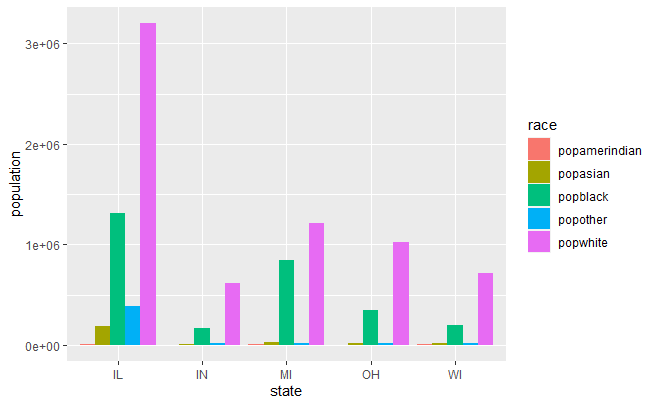

```r
ggplot(data = state_race_long) +
  geom_col(aes(x = state, y = population, fill = race),
           position = "dodge")
```

## Styling with Scales

Whenever you specify an aesthetic mapping, `ggplot2` uses a particular *scale* to determine the *range* of values that the data encoding should be mapped *to*. Thus, when you specify a plot such as:

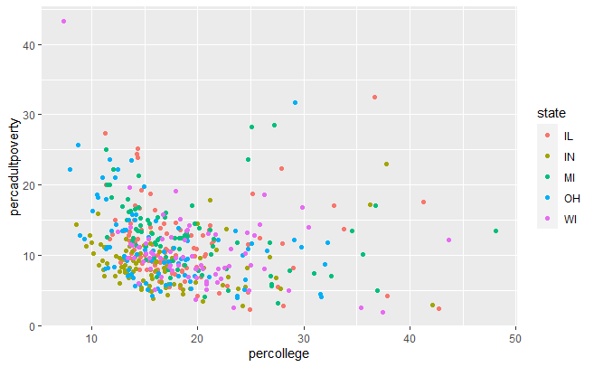

```r
# Plot the `midwest` data set, with college education rate on the x-axis and
# percentage of adult poverty on the y-axis. Color by state.
ggplot(data = midwest) +
  geom_point(mapping = aes(x = percollege, y = percadultpoverty,
                           color = state))
```

`ggplot2` automatically adds a scale for each mapping to the plot:

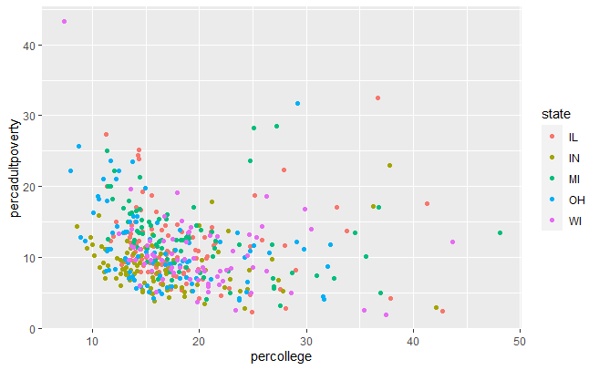

```r
# explicitly set the scales:
ggplot(data = midwest) +
  geom_point(mapping = aes(x = percollege, y = percadultpoverty,
                           color = state)) +
  scale_x_continuous() +
  scale_y_continuous() +
  scale_color_discrete()
```

Each scale can be represented by a function named in the following format: `scale_`, followed by the name of the aesthetic property (e.g., `x` or `color`), followed by an `_` and the type of the scale (e.g., `continuous` or `discrete`). A continuous scale will handle values such as numeric data (where there is a *continuous* set of numbers), whereas a *discrete* scale will handle values such as colors (since there is a small discrete list of distinct colors). Notice also that scales are added to a plot using the `+` operator, similar to a `geom` layer.

While the default scales will often suffice for your plots, it is possible to explicitly add different scales to replace the defaults. For example, you can use a scale to change the direction of an axis (`scale_x_reverse()`), or plot the data on a logarithmic scale (`scale_x_log10()`). You can also use scales to specify the range of values on an axis by passing in a `limits` argument. Explicit limits are useful for making sure that multiple graphs share scales or formats, as well as for customizing the appearance of your visualizations.

For example:

- Create a label for the `inmetro` column:

```r
midwest_labeled <- midwest %>%
                    mutate(location = if_else(inmetro ==  0, "Rural", "Urban"))
```

- Subset the data for Wisconsin and Michigan:

```r
wisconsin_data <- midwest_labeled %>% filter(state == "WI")
michigan_data <- midwest_labeled %>% filter(state == "MI")
```

- Define continuous scales based on the entire dataset (use the `range()` function that determines the minimum and maximum values, and define the `limits`)

```r
x_scale <- scale_x_continuous(limits = range(midwest_labeled$percollege))
y_scale <- scale_y_continuous(limits = range(midwest_labeled$percadultpoverty))
```

- Define a discrete color scale using the unique set of locations (Urban/Rural)

```r
color_scale <- scale_color_discrete(limits = unique(midwest_labeled$location))
```

- Plot the data for Wisconsin:

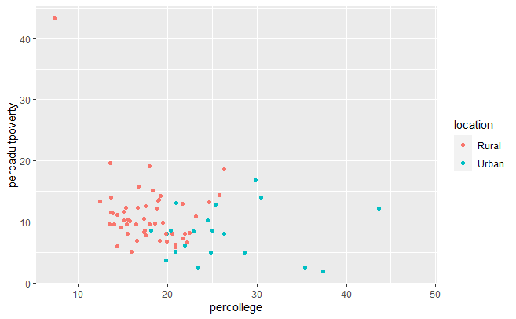

```r
ggplot(data = wisconsin_data) +
  geom_point(aes(x = percollege, y = percadultpoverty, color = location)) +
  x_scale +
  y_scale +
  color_scale
```

- Plot the data for Michigan:

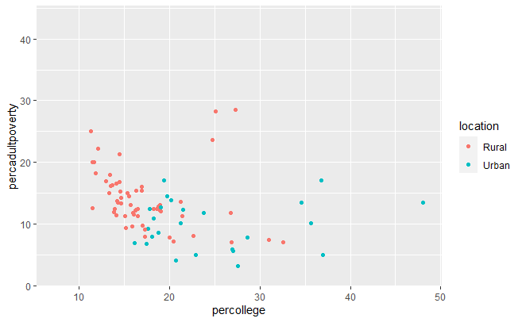

```r
ggplot(data = michigan_data) +
  geom_point(aes(x = percollege, y = percadultpoverty, color = location)) +
  x_scale +
  y_scale +
  color_scale
```

These scales can also be used to specify the tick marks and labels; see the `ggplot2` documentation for details.

## Color Scale

One of the most common scales to change is the color scale (i.e., the set of colors used in a plot). While you can use scale functions such as `scale_color_manual()` to specify a specific set of colors for your plot, a more common option is to use one of the predefined ColorBrewer palettes. These palettes can be specified as a color scale with the `scale_color_brewer()` function, passing the palette as a named argument.

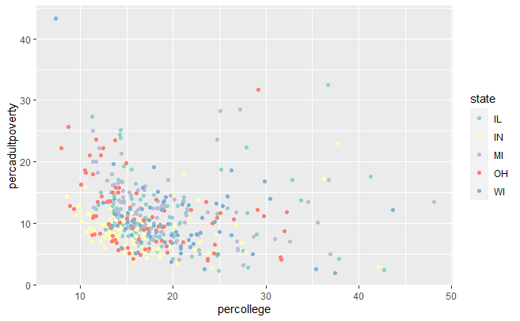

```r
ggplot(data = midwest_labeled) +
  geom_point(aes(x = percollege, y = percadultpoverty, color = state)) +
  scale_color_brewer(palette = "Set3")
```

For discrete color scales, you can specify a distinct set of colors to map to using a function such as [`scale_color_manual()`](http://ggplot2.tidyverse.org/reference/scale_manual.html).

For continuous color scales, you can specify a range of colors to display using a function such as [`scale_color_gradient()`](http://ggplot2.tidyverse.org/reference/scale_gradient.html).

## Coordinate Systems

It is also possible to specify a plot’s **coordinate system**, which is used to organize the geometric objects. As with scales, coordinate systems are specified with functions (whose names all start with `coord_`) and are added to a `ggplot`. You can use several different [coordinate systems](http://ggplot2.tidyverse.org/reference/index.html#section-coordinate-systems), including but not limited to the following:

- `coord_cartesian()`: The default Cartesian coordinate system, where you specify `x` and `y` values—x values increase from left to right, and y values increase from bottom to top
- `coord_flip()`: A Cartesian system with the `x` and `y` flipped
- `coord_fixed()`: A Cartesian system with a “fixed” aspect ratio (e.g., 1.78 for “widescreen”)
- `coord_polar()`: A plot using polar coordinates (i.e., a pie chart)
- `coord_quickmap()`: A coordinate system that approximates a good aspect ratio for maps. See the documentation for more details.

The following example uses `coord_flip()` to create a horizontal bar chart (a useful layout for making labels more legible).

- First create an auxiliary dataframe with the top 10 most populous counties:

```r
midwest %>%
  top_n(n = 10, wt = poptotal) %>%
  unite(county_state, county, state, sep = ", ") %>%
  arrange(poptotal) %>%
  mutate(location = factor(county_state, county_state)) # set row order
```

| PID | county_state | area | poptotal | popdensity | popwhite | popblack | popamerindian | popasian | popother | percwhite | percblack | percamerindan | percasian | percother | popadults | perchsd | percollege | percprof | poppovertyknown | percpovertyknown | percbelowpoverty | percchildbelowpovert | percadultpoverty | percelderlypoverty | inmetro | category | location |
| --- | --- | --- | --- | --- | --- | --- | --- | --- | --- | --- | --- | --- | --- | --- | --- | --- | --- | --- | --- | --- | --- | --- | --- | --- | --- | --- | --- |
| 1246 | MACOMB, MI | 0.028 | 717400 | 25621.43 | 693686 | 10400 | 2639 | 9112 | 1563 | 96.69445 | 1.449679 | 0.3678561 | 1.2701422 | 0.2178701 | 472323 | 76.92871 | 20.68669 | 4.430019 | 710217 | 98.99875 | 5.193061 | 7.356104 | 4.101367 | 5.952192 | 1 | ALU | MACOMB, MI |
| 582 | DU PAGE, IL | 0.020 | 781666 | 39083.30 | 714905 | 15462 | 962 | 39634 | 10703 | 91.45914 | 1.978083 | 0.1230705 | 5.0704521 | 1.3692549 | 502321 | 88.57683 | 42.76887 | 11.963266 | 771641 | 98.71748 | 2.714734 | 2.945252 | 2.399064 | 3.838249 | 1 | HLU | DU PAGE, IL |
| 711 | MARION, IN | 0.023 | 797159 | 34659.09 | 615039 | 169654 | 1698 | 7579 | 3189 | 77.15387 | 21.282329 | 0.2130064 | 0.9507514 | 0.4000457 | 511309 | 76.80463 | 26.74469 | 7.686546 | 780649 | 97.92889 | 12.058044 | 18.155412 | 9.763275 | 10.725964 | 1 | AAU | MARION, IN |
| 2039 | HAMILTON, OH | 0.025 | 866228 | 34649.12 | 672972 | 181145 | 1204 | 9198 | 1709 | 77.68994 | 20.911931 | 0.1389934 | 1.0618451 | 0.1972922 | 551233 | 75.64968 | 29.78831 | 8.617227 | 846909 | 97.76976 | 13.292455 | 19.570569 | 11.169832 | 10.696061 | 1 | AAU | HAMILTON, OH |
| 3021 | MILWAUKEE, WI | 0.015 | 959275 | 63951.67 | 718918 | 195470 | 6994 | 15308 | 22585 | 74.94389 | 20.376847 | 0.7290923 | 1.5957885 | 2.3543822 | 610538 | 76.26045 | 25.35583 | 6.201252 | 933532 | 97.31641 | 15.873478 | 27.798026 | 12.889589 | 7.813748 | 1 | AAU | MILWAUKEE, WI |
| 2033 | FRANKLIN, OH | 0.034 | 961437 | 28277.56 | 783714 | 152840 | 2056 | 19437 | 3390 | 81.51486 | 15.897037 | 0.2138466 | 2.0216613 | 0.3525972 | 597303 | 80.99876 | 32.20459 | 9.140922 | 935142 | 97.26503 | 12.990006 | 17.637868 | 11.818383 | 9.749349 | 1 | HAU | FRANKLIN, OH |
| 1259 | OAKLAND, MI | 0.055 | 1083592 | 19701.67 | 970674 | 77488 | 3948 | 25103 | 6379 | 89.57929 | 7.151031 | 0.3643438 | 2.3166469 | 0.5886902 | 717210 | 84.63449 | 36.96351 | 11.220563 | 1070844 | 98.82354 | 6.043644 | 8.452007 | 4.949889 | 6.477303 | 1 | HLU | OAKLAND, MI |
| 2026 | CUYAHOGA, OH | 0.026 | 1412140 | 54313.08 | 1025756 | 350185 | 2533 | 18085 | 15581 | 72.63841 | 24.798179 | 0.1793732 | 1.2806804 | 1.1033609 | 943924 | 74.01306 | 25.08539 | 7.356736 | 1388547 | 98.32927 | 13.766117 | 21.580976 | 11.675506 | 10.213391 | 1 | AAU | CUYAHOGA, OH |
| 1278 | WAYNE, MI | 0.035 | 2111687 | 60333.91 | 1212007 | 849109 | 8048 | 21704 | 20819 | 57.39520 | 40.209984 | 0.3811171 | 1.0278038 | 0.9858942 | 1324635 | 69.95157 | 19.41040 | 4.985751 | 2084529 | 98.71392 | 20.065300 | 30.564270 | 17.066226 | 13.247350 | 1 | AHU | WAYNE, MI |
| 576 | COOK, IL | 0.058 | 5105067 | 88018.40 | 3204947 | 1317147 | 10289 | 188565 | 384119 | 62.77972 | 25.800778 | 0.2015449 | 3.6936832 | 7.5242695 | 3291995 | 73.40582 | 28.01812 | 8.329964 | 5023523 | 98.40269 | 14.198303 | 22.293497 | 11.665542 | 10.825269 | 1 | AAU | COOK, IL |

New dataframe:

```r
top_10 <- midwest %>%
  top_n(n = 10, wt = poptotal) %>%
  unite(county_state, county, state, sep = ", ") %>%
  arrange(poptotal) %>%
  mutate(location = factor(county_state, county_state))
```

- Render a horizontal bar chart of population:

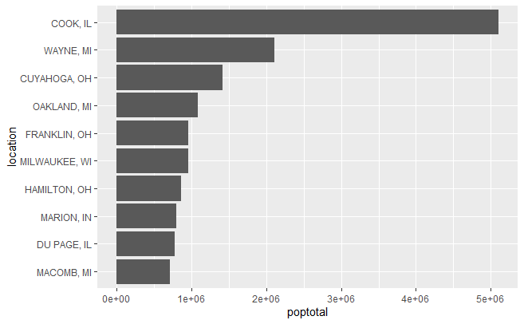

```r
ggplot(data = top_10) +
  geom_col(aes(x = location, y = poptotal)) +
  coord_flip()
```

## Facets

Facets are ways of grouping a visualization into *multiple different pieces* (subplots). This allows you to view a separate plot for each unique value in a categorical variable. Conceptually, breaking a plot up into facets is similar to using the `group_by()` verb in `dplyr`: it creates the same visualization for each group separately (just as `summarize()` performs the same analysis for each group).

You can construct a plot with multiple facets by using a `facet_` function such as `facet_wrap()`. This function will produce a “row” of subplots, *one for each categorical variable* (the number of rows can be specified with an additional argument); subplots will “wrap” to the next line if there is not enough space to show them all in a single row.

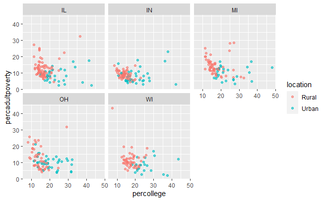

```r
ggplot(data = midwest_labeled) +
  geom_point(aes(x = percollege, y = percadultpoverty, color = location),
             alpha = 0.6) +
  facet_wrap(~state) # pass the `state` column as a formular to facet_wrap()
```

Note that the argument to the `facet_wrap()` function is the column to facet by, with the column name written with a tilde (`~`) in front of it, turning it into a *formula*. The tilde (`~`) can be read *“as a function of”*.

## Labels and Annotation

Textual labels and annotations that more clearly express the meaning of axes, legends, and markers are an important part of making a plot understandable and communicating information. Although not an explicit part of the Grammar of Graphics (they would be considered a form of geometry), `ggplot2` provides functions for adding such annotations.

You can add titles and axis labels to a chart using the `labs()` function. This function takes named arguments for each aspect to label—either `title` (or `subtitle` or `caption`), or the name of the aesthetic (e.g., `x`, `y`, `color`). Axis aesthetics such as `x` and `y` will have their label shown on the axis, while other aesthetics will use the provided label for the legend.

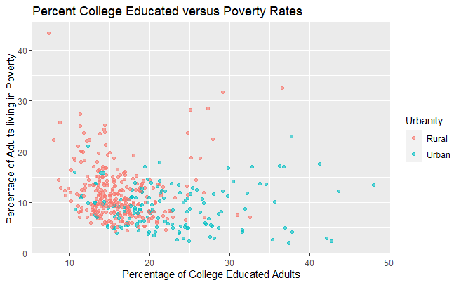

```r
ggplot(data = midwest_labeled) +
  geom_point(aes(x = percollege, y = percadultpoverty, color = location),
             alpha = 0.6) +
  labs(
    title = "Percent College Educated versus Poverty Rates",
    x = "Percentage of College Educated Adults",
    y = "Percentage of Adults living in Poverty",
    color = "Urbanity"
  )
```

- First create an auxiliary dataframe with highest level of poverty in each state:

```r
most_poverty <- midwest %>%
  group_by(state) %>%
  top_n(1, wt = percadultpoverty) %>% # seelcts the highest poverty county
  unite(county_state, county, state, sep = ", ") #nicer labeling
```

- Store the subtitle in a variable for cleaner code:

```r
mysubtitle <- "(the county with the highest level of poverty in each state is labeled)"
```

- Plot the data with labels

[output not shown]

[figure not shown]

```r
library(ggrepel)
ggplot(data = midwest_labeled, aes(x = percollege, y = percadultpoverty)) +
  geom_point(aes(color = location), alpha = 0.6) +
  geom_label_repel(
    data = most_poverty,
    aes(label = county_state),
    alpha = 0.8
  ) +
  labs(title = "Percent College Educated versus Poverty Rates",
       subtitle = mysubtitle,
       x = "Percentage of College Educated Adults",
       y = "Percentage of Adults living in Poverty",
       color = "Urbanity" ,
       caption = "Data source: 2000 US Census"
       ) +
  scale_x_continuous(limits = c(0, 55))
```